# **Retail Analytics Solution & Shiny Web Application**

================================================================================

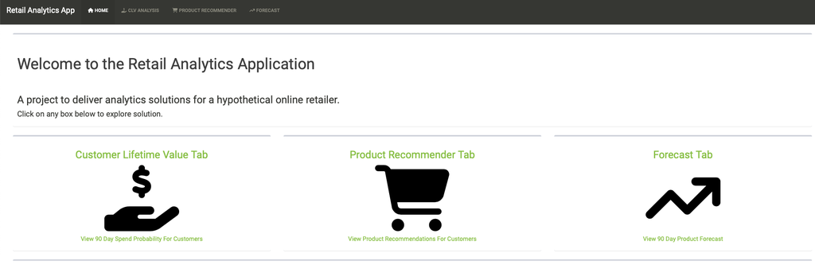

### **Project Overview**

- **Goal:** Create a 3 part retail analytics solution for an online retailer.
- **Data:** Dataset is the popular online retail dataset from [Kaggle](https://www.kaggle.com/datasets/mashlyn/online-retail-ii-uci).
- **Analysis Approach:** Customer Lifetime Value, Product Recommendations and Forecasting.
- **Deployment:** Created a shiny web application with a user friendly interface.
- **Tools/Packages:**
  - [Tidyverse](https://www.tidyverse.org) - For data wrangling.
  - [Tidymodels](https://www.tidymodels.org) - For machine learning.
  - [Coop](https://cran.r-project.org/web/packages/coop/index.html) - For building product recommendation system.
  - [Modeltime](https://business-science.github.io/modeltime/) - For forecasting with machine learning.
  - [Shiny](https://shiny.rstudio.com) - For building web application.

================================================================================

### **Solution Details**

#### **Solution 1: Customer Lifetime Value (CLV)**

This solution benefits the marketing team by using machine learning to understand/predict the probability of a customer making a purchase within a certain time frame as well as how much the customer might spend. RFM (Recency, Frequency and Monetary) features were extracted and used as predictors. Additionally, this analysis focuses on a particular cohort of customers, i.e the customers with a first purchase date in Q1 2010. This represents the largest cohort of customers in terms of first purchase dates.

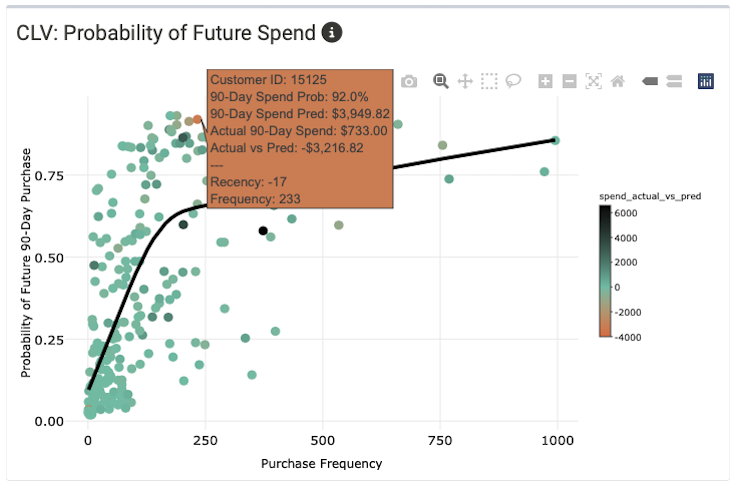

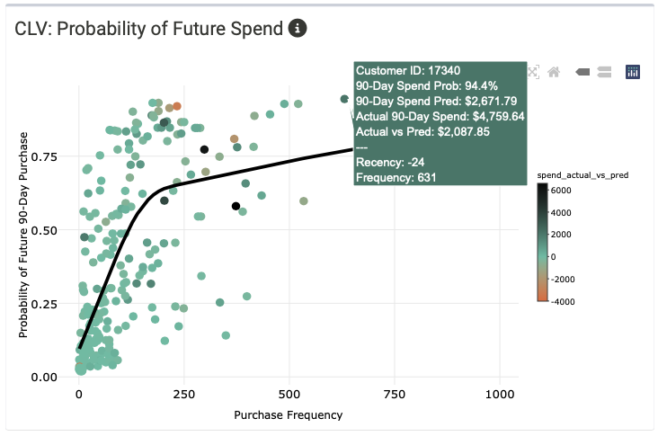

This customer also had a high probability of making a purchase and did spend $2K higher than the model predicted ($4759 actual vs $2671 predicted). This customer will be a prime candidate to further analyze, understand their spending habits, see what products they are purchasing, and recommend similar products to similar customers with low spend.

**Caveat -** The model used to make predictions for the CLV analysis did not involve hyper-parameter tuning, hence some of the large variances between predicted and actual spend values. In a real business case, we can improve the performance of a prediction model by doing hyper-parameter tuning.

#### **Solution 2: Product Recommendations**

Builds on the CLV Analysis by using Collaborative Filtering to recommend products to customers to customers based on what similar customers have purchased in the prior 90 days. For example we see that customer 15125 purchased $3K less than predicted. We can recommend new products to this customer based on what similar customers have purchased.

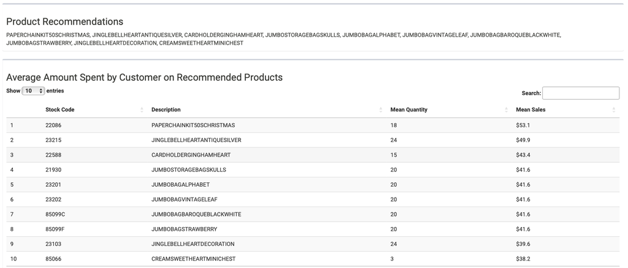

**Caveat -** This analysis use [user-based collaborative filtering](https://www.geeksforgeeks.org/user-based-collaborative-filtering/), which recommends products based on what similar customers have purchased. Meaning that a customer has to have made a purchase in the analysis time frame in order to find similarities with other customers and thus recommend products. In a real business case, there may be situations where an [item-based collaborative filtering](https://www.geeksforgeeks.org/item-to-item-based-collaborative-filtering/) method is used instead. This method uses relationships between pairs of products to recommend new products to customers.

#### **Solution 3: Sales Forecasting**

This solutions provides a high level forecast of quantity of products sold. For this analysis, a 90 day forecast horizon was used. Forecast hierarchy was broken out by United Kingdom vs all other countries. This is due to the fact that the UK accounts for 85% of product sales (on average). Once again this forecast benefits the marketing, sale and purchasing teams with planning inventory levels for future sales.

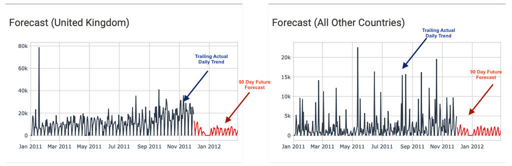